AGR5266 - Individual Project

Author

Affiliation

Hernandes Peres Panichi (hp.panichi@ufl.edu)

Ph.D, University of Florida

```r
remove(list = ls())
library(tidyverse)
library(asreml)
library(mvngGrAd)
library(SpATS)
library(kableExtra)
library(patchwork)

load('mydata.Rdata')
source('SpatialAnalysisFun.R')

df.ty = mydata %>%
  filter(year_trial == '2026_I4' & trait == 'TY') %>%
  droplevels() %>%
  select(row, col, check, rep, clone, trait, value) %>%
  arrange(row, col)

df.sg = mydata %>%
  filter(year_trial == '2026_I4' & trait == 'SG') %>%
  droplevels() %>%
  select(row, col, check, rep, clone, trait, value) %>%
  arrange(row, col)
```

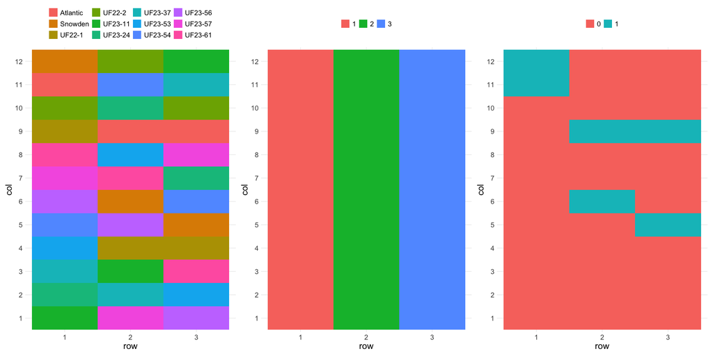

```r
# --- Store results

AIC = matrix(NA, 6)
BIC = matrix(NA, 6)
H2 = matrix(NA, 6)
varG = matrix(NA, 6)
```

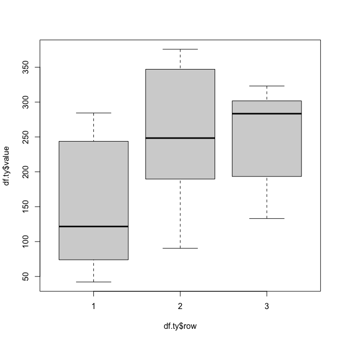

```r
# --- TY
boxplot(df.ty$value~df.ty$row)
```

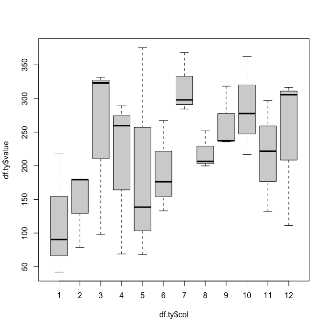

```r
boxplot(df.ty$value~df.ty$col)
```

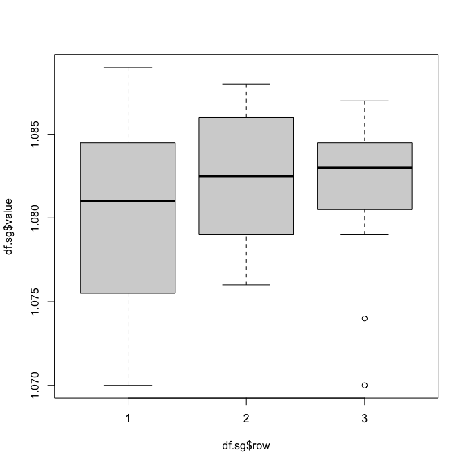

```r
# --- SG
boxplot(df.sg$value~df.sg$row)
```

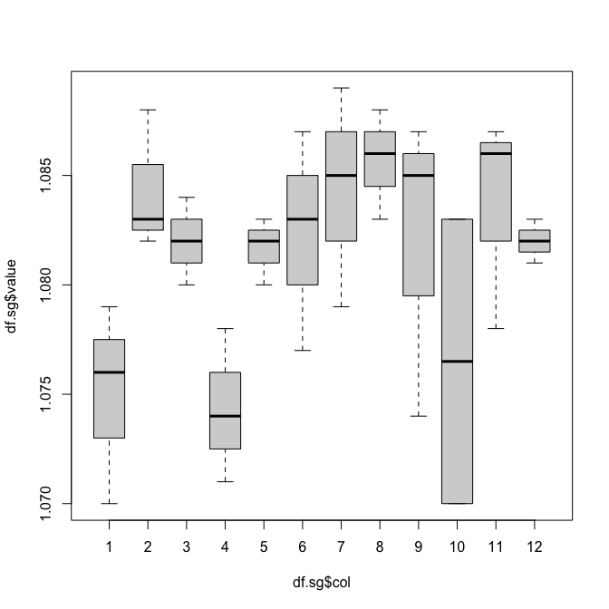

```r
boxplot(df.sg$value~df.sg$col)
```

#### **Model 1**

$$y_{ijk} = \mu + C_k+B_j+G_i+e_{ijk}$$

- $\mu$ Overal mean
- $C_k$ Vector of fixed checks effects
- $R_j$ Vector of fixed blocks effects
- $G_i$ Vector of random genotypes effects, $\sim N(0, I\sigma_g^2)$
- $e_{ijk}$ Vector of random residual effects, $\sim N(0, I\sigma_{e}^2)$

**Testing significance of random effect (Genotypes)**

As we want to verify the difference between the genotypes. And `clone` was modeled as random effects, by simple testing:

- $H_0:\sigma_g = 0$
- $H_a:\sigma_g \neq 0$

We can verify if there is variability between them by performing an ANOVA or Mixed Models.

#### ANOVA

$$y_{ijk} = \mu +B_j+G_i+e_{ijk}$$

$$y_{ijk} = \mu +C_k+B_j+G_i+e_{ijk}$$

Where:

- $C_k$ is effects of checks - if included
- $B_j$ is the effects of Blocks
- $G_i$ is the effects of genotypes
- $e_{ijk}$ is the residual

```r
M1_A.ty = lm(value~rep+clone, data = df.ty)
M1_A.sg = lm(value~rep+clone, data = df.sg)
anova(M1_A.ty)
```

```
Analysis of Variance Table

Response: value
          Df Sum Sq Mean Sq F value   Pr(>F)
rep        2  80360   40180  7.2512 0.003812 **
clone     11 111801   10164  1.8342 0.108826
Residuals 22 121905    5541
---
Signif. codes:  0 '***' 0.001 '**' 0.01 '*' 0.05 '.' 0.1 ' ' 1
```

```r
anova(M1_A.sg)
```

```
Analysis of Variance Table

Response: value
          Df     Sum Sq    Mean Sq F value  Pr(>F)
rep        2 0.00002826 1.4132e-05  0.8114 0.45770
clone     11 0.00050111 4.5555e-05  2.6154 0.02801 *
Residuals 21 0.00036577 1.7418e-05
---
Signif. codes:  0 '***' 0.001 '**' 0.01 '*' 0.05 '.' 0.1 ' ' 1
```

```r
M1_A2.ty = lm(value~check+rep+clone,data = df.ty)
M1_A2.sg = lm(value~check+rep+clone, data = df.sg)
anova(M1_A2.ty)
```

```
Analysis of Variance Table

Response: value
          Df Sum Sq Mean Sq F value   Pr(>F)
check      1   9070    9070  1.6368 0.214094
rep        2  80360   40180  7.2512 0.003812 **
clone     10 102731   10273  1.8540 0.109366
Residuals 22 121905    5541
---
Signif. codes:  0 '***' 0.001 '**' 0.01 '*' 0.05 '.' 0.1 ' ' 1
```

```r
anova(M1_A2.sg)
```

```
Analysis of Variance Table

Response: value
          Df     Sum Sq    Mean Sq F value  Pr(>F)
check      1 0.00010907 1.0907e-04  6.2619 0.02067 *
rep        2 0.00002818 1.4090e-05  0.8090 0.45872
clone     10 0.00039212 3.9212e-05  2.2513 0.05633 .
Residuals 21 0.00036577 1.7418e-05
---
Signif. codes:  0 '***' 0.001 '**' 0.01 '*' 0.05 '.' 0.1 ' ' 1
```

```r
# --- Total Yield (TY)
M1.ty = asreml(value ~ 1+check+rep,
               random = ~clone,
               na.action = na.method(x = "include"),
               data = df.ty)

AIC[1] = as.numeric(summary(M1.ty)$aic[1])
BIC[1] = as.numeric(summary(M1.ty)$bic[1])
H2[1] = as.numeric(vpredict(M1.ty, H2~V1/(V1+V2))[1])
varG[1] = as.numeric(summary(M1.ty)$varcomp[1,1])

M1r.ty = asreml(value ~ 1+check+rep,
                na.action = na.method(x = "include"),
                data = df.ty)

lrt(M1.ty, M1r.ty, boundary = T)
```

```
Likelihood ratio test(s) assuming nested random models.
(See Self & Liang, 1987)

             df LR-statistic Pr(Chisq)
M1.ty/M1r.ty  1       1.3962    0.1187
```

```r
# --- Specific gravity (SG)
M1.sg = asreml(value ~1+check+rep,
               random = ~clone,
               na.action = na.method(x = "include"),
               data = df.sg)

AIC[4] = as.numeric(summary(M1.sg)$aic[1])
BIC[4] = as.numeric(summary(M1.sg)$bic[1])
H2[4] = as.numeric(vpredict(M1.sg, H2~V1/(V1+V2))[1])
varG[4] = as.numeric(summary(M1.sg)$varcomp[1,1])

M1r.sg = asreml(value ~1+check+rep,
                na.action = na.method(x = "include"),
                data = df.sg)

lrt(M1.sg, M1r.sg)
```

```
Likelihood ratio test(s) assuming nested random models.
(See Self & Liang, 1987)

             df LR-statistic Pr(Chisq)
M1.sg/M1r.sg  1       2.2888   0.06516 .
---
Signif. codes:  0 '***' 0.001 '**' 0.01 '*' 0.05 '.' 0.1 ' ' 1
```

```r
df.ty %>% group_by(clone) %>%
  dplyr::summarise(mean = mean(value)) %>%
  arrange(desc(mean))
```

```
# A tibble: 12 × 2
   clone     mean
   <fct>    <dbl>
 1 UF23-61   314.
 2 UF23-56   287.
 3 UF22-2    270.
 4 UF22-1    261.
 5 UF23-24   246.
 6 Atlantic  229.
 7 UF23-11   226.
 8 UF23-57   194.
 9 UF23-37   191.
10 UF23-53   150.
11 Snowden   142.
12 UF23-54   141.
```

```r
df.sg %>% group_by(clone) %>%
  dplyr::summarise(mean = mean(value)) %>%
  arrange(desc(mean))
```

```
# A tibble: 12 × 2
   clone     mean
   <fct>    <dbl>
 1 Atlantic  1.09
 2 UF23-37   1.09
 3 UF23-61   1.09
 4 Snowden   1.08
 5 UF23-57   1.08
 6 UF23-24   1.08
 7 UF23-11   1.08
 8 UF23-54   1.08
 9 UF23-53   1.08
10 UF23-56   1.08
11 UF22-1    1.08
12 UF22-2   NA
```

#### **Model 2:**(AR1 x AR1)

Modeling autoregressive correlation of residuals (AR1 x AR1)

$$y_{ijk} = \mu+C_k+B_j+G_i+e_{ijk}$$

- $e_{ijk}$ Vector of random residual effects, $\sim N(0, \sigma_e\Sigma_r(\rho_r)\otimes\Sigma_c(\rho_c))$

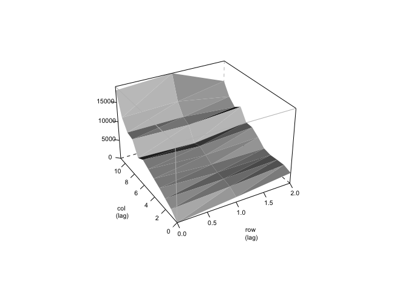

```r
# --- TY
M2.ty = asreml(value ~ 1+check+rep,
               random = ~ clone,
               na.action = na.method(x = 'include'),
               residual = ~ar1(row):ar1(col),
               data = df.ty)

AIC[2] = as.numeric(summary(M2.ty)$aic[1])
BIC[2] = as.numeric(summary(M2.ty)$bic[1])
H2[2] = as.numeric(vpredict(M2.ty, H2~V1/(V1+V2))[1])
varG[2] = as.numeric(summary(M2.ty)$varcomp[1,1])

plot(varioGram(M2.ty))
```

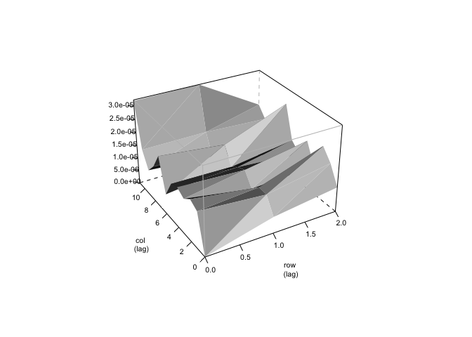

```r
# --- SG

M2.sg = asreml(value ~ 1+check+rep,
               random = ~ clone,
               na.action = na.method(x = 'include'),
               residual = ~ar1(row):ar1(col),
               data = df.sg)

AIC[5] = as.numeric(summary(M2.sg)$aic[1])
BIC[5] = as.numeric(summary(M2.sg)$bic[1])
H2[5] = as.numeric(vpredict(M2.sg, H2~V1/(V1+V2))[1])
varG[5] = as.numeric(summary(M2.sg)$varcomp[1,1])

plot(varioGram(M2.sg))
```

```r
M2r.ty = asreml(value ~ 1+check+rep,
                na.action = na.method(x = 'include'),
                residual = ~ar1(row):ar1(col),
                data = df.ty)

M2r.sg = asreml(value ~ 1+check+rep,
                na.action = na.method(x = 'include'),
                residual = ~ar1(row):ar1(col),
                data = df.sg)

lrt(M2.ty, M2r.ty)
```

```
Likelihood ratio test(s) assuming nested random models.
(See Self & Liang, 1987)

             df LR-statistic Pr(Chisq)
M2.ty/M2r.ty  1       9.3617  0.001108 **
---
Signif. codes:  0 '***' 0.001 '**' 0.01 '*' 0.05 '.' 0.1 ' ' 1
```

```r
lrt(M2.sg, M2r.sg)
```

```
Likelihood ratio test(s) assuming nested random models.
(See Self & Liang, 1987)

             df LR-statistic Pr(Chisq)
M2.sg/M2r.sg  1       2.7056      0.05 *
---
Signif. codes:  0 '***' 0.001 '**' 0.01 '*' 0.05 '.' 0.1 ' ' 1
```

Now, the genotype random term has variability within its levels.

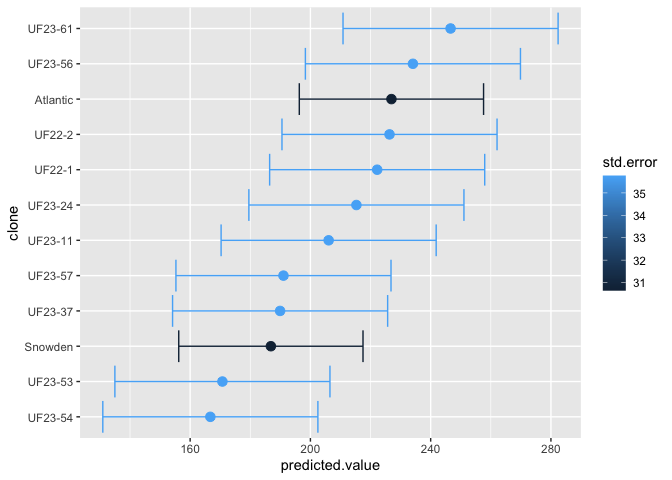

```r
predM1.ty = as.data.frame(predict(M1.ty, 'clone')$pvals)
predM1.ty = predM1.ty %>% arrange((predicted.value)) %>%
  mutate(clone = fct_inorder(clone))

predM1.ty %>%
  ggplot(aes(y = clone, x = predicted.value, color = std.error)) +
  geom_point(size = 3) +
  geom_errorbar(aes(xmin = predicted.value - std.error,
                    xmax = predicted.value + std.error,
                    color = std.error),
                orientation = "y")
```

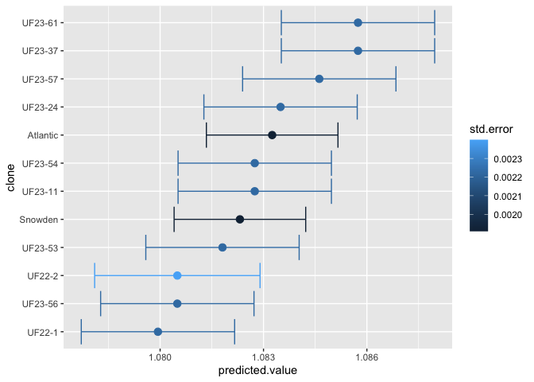

```r
predM1.sg = as.data.frame(predict(M1.sg, 'clone')$pvals)
predM1.sg = predM1.sg %>% arrange((predicted.value)) %>%
  mutate(clone = fct_inorder(clone))

predM1.sg %>%
  ggplot(aes(y = clone, x = predicted.value, color = std.error)) +
  geom_point(size = 3) +
  geom_errorbar(aes(xmin = predicted.value - std.error,
                    xmax = predicted.value + std.error,
                    color = std.error),
                orientation = "y")
```

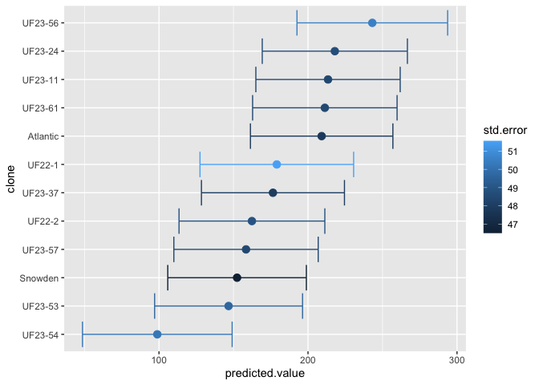

```r
## -
predM2.ty = as.data.frame(predict(M2.ty, 'clone')$pvals)
predM2.ty = predM2.ty %>% arrange((predicted.value)) %>%
  mutate(clone = fct_inorder(clone))

predM2.ty %>%
  ggplot(aes(y = clone, x = predicted.value, color = std.error)) +
  geom_point(size = 3) +
  geom_errorbar(aes(xmin = predicted.value - std.error,
                    xmax = predicted.value + std.error,
                    color = std.error),
                orientation = "y")
```

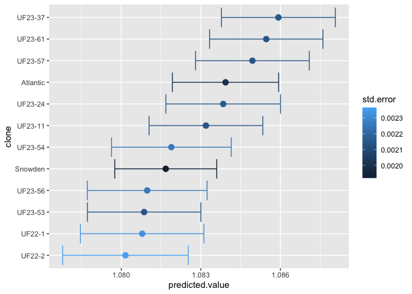

```r
predM2.sg = as.data.frame(predict(M2.sg, 'clone')$pvals)
predM2.sg = predM2.sg %>% arrange((predicted.value)) %>%
  mutate(clone = fct_inorder(clone))

predM2.sg %>%
  ggplot(aes(y = clone, x = predicted.value, color = std.error)) +
  geom_point(size = 3) +
  geom_errorbar(aes(xmin = predicted.value - std.error,
                    xmax = predicted.value + std.error,
                    color = std.error),
                orientation = "y")
```

#### **Model 3:** AR1, with fixed column

$$y_{ijkl} = \mu +C_k+B_j+COL_l+G_i+e_{ijkl}$$

- $\mu$ Overal mean
- $C_k$ Vector of fixed checks effects
- $B_j$ Vector of fixed blocks effects
- $COL_l$ Vector of fixed collumns effects
- $G_i$ Vector of random genotypes effects, $\sim N(0, I\sigma_g^2)$
- $e_{ijkl}$ Vector of random residual effects, $\sim N(0, \Sigma_r(\rho_r)\otimes\Sigma_c(\rho_c))$

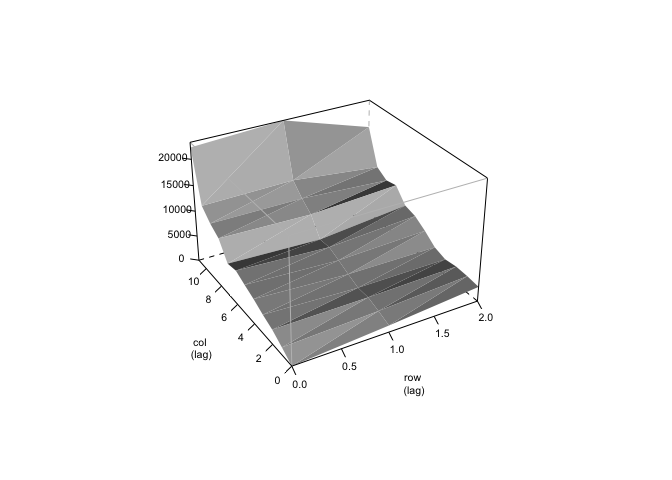

```r
df.ty$Fcol = 1
df.ty$Fcol[df.ty$col %in% seq(1,12,2)] = 2
df.ty$Fcol= factor(as.numeric(trimws(df.ty$Fcol)))
df.ty$Frow = factor(as.numeric(df.ty$row))

df.sg$Fcol = 1
df.sg$Fcol[df.sg$col %in% seq(1,12,2)] = 2
df.sg$Fcol= factor(as.numeric(trimws(df.sg$Fcol)))
df.sg$Frow = factor(as.numeric(df.sg$row))

# --- TY
M3.ty = asreml(value ~ 1+check+rep+Fcol,
               random = ~clone,
               na.action = na.method(x = "include"),
               residual = ~ar1(row):ar1(col),
               data = df.ty)

AIC[3] = as.numeric(summary(M3.ty)$aic[1])
BIC[3] = as.numeric(summary(M3.ty)$bic[1])
H2[3] = as.numeric(vpredict(M3.ty, H2~V1/(V1+V2))[1])
varG[3] = as.numeric(summary(M3.ty)$varcomp[1,1])
plot(varioGram(M3.ty))
```

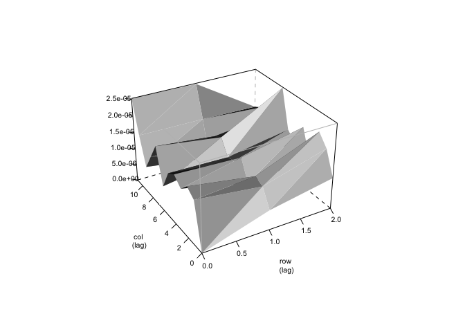

```r
# --- SG
M3.sg = asreml(value ~ 1+check+rep+Fcol,
               random = ~clone,
               na.action = na.method(x = "include"),
               residual = ~ar1(row):ar1(col),
               data = df.sg)

AIC[6] = as.numeric(summary(M3.sg)$aic[1])
BIC[6] = as.numeric(summary(M3.sg)$bic[1])
H2[6] = as.numeric(vpredict(M3.sg, H2~V1/(V1+V2))[1])
varG[6] = as.numeric(summary(M3.sg)$varcomp[1,1])
plot(varioGram(M3.sg))
```

```r
M3r.ty = asreml(value ~ 1+check+rep+Fcol,
                na.action = na.method(x = "include"),
                residual = ~ar1(row):ar1(col),
                data = df.ty)

lrt(M3.ty, M3r.ty)
```

```
Likelihood ratio test(s) assuming nested random models.
(See Self & Liang, 1987)

             df LR-statistic Pr(Chisq)
M3.ty/M3r.ty  1       9.1867  0.001219 **
---
Signif. codes:  0 '***' 0.001 '**' 0.01 '*' 0.05 '.' 0.1 ' ' 1
```

```r
M3r.sg = asreml(value ~ 1+check+rep+Fcol,
                na.action = na.method(x = "include"),
                residual = ~ar1(row):ar1(col),
                data = df.sg)

lrt(M3.sg, M3r.sg)
```

```
Likelihood ratio test(s) assuming nested random models.
(See Self & Liang, 1987)

             df LR-statistic Pr(Chisq)
M3.sg/M3r.sg  1       2.9767   0.04224 *
---
Signif. codes:  0 '***' 0.001 '**' 0.01 '*' 0.05 '.' 0.1 ' ' 1
```

Using LRT test, the genotype random term has variability within its levels.

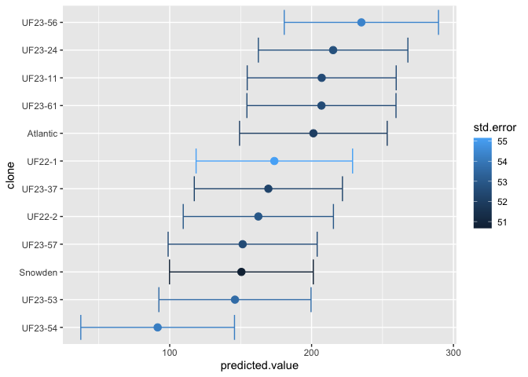

```r
predM3.ty = as.data.frame(predict(M3.ty, 'clone')$pvals)
predM3.ty = predM3.ty %>% arrange((predicted.value)) %>%
  mutate(clone = fct_inorder(clone))

predM3.ty %>%
  ggplot(aes(y = clone, x = predicted.value, color = std.error)) +
  geom_point(size = 3) +
  geom_errorbar(aes(xmin = predicted.value - std.error,
                    xmax = predicted.value + std.error,
                    color = std.error),
                orientation = "y")
```

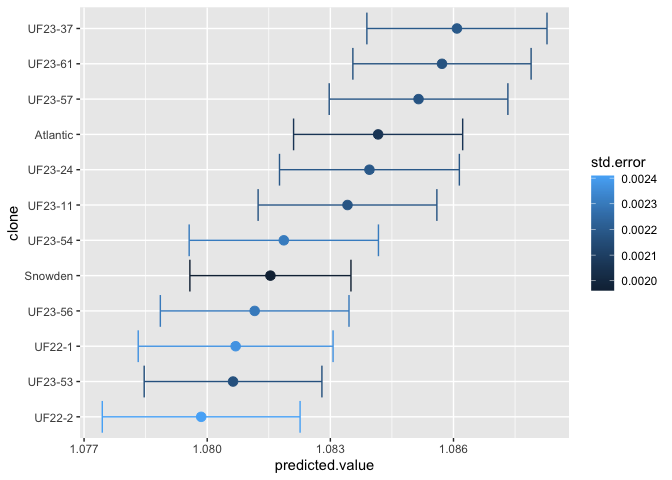

```r
predM3.sg = as.data.frame(predict(M3.sg, 'clone')$pvals)
predM3.sg = predM3.sg %>% arrange((predicted.value)) %>%
  mutate(clone = fct_inorder(clone))

predM3.sg %>%
  ggplot(aes(y = clone, x = predicted.value, color = std.error)) +
  geom_point(size = 3) +
  geom_errorbar(aes(xmin = predicted.value - std.error,
                    xmax = predicted.value + std.error,
                    color = std.error),
                orientation = "y")
```

#### **Getting AIC, BIC, $H^2$ and ranking$**

$$H^2 = \frac{\sigma_g^2}{\sigma_g^2+\sigma_e^2}$$

$$r = \sqrt{H^2}$$

```r
ans = data.frame(Trait = rep(c("TY","SG"), each = 3),
                 model = as.factor(paste0("M", 1:6)),
                 AIC,
                 BIC,
                 varG,
                 H2)

kable(ans, format = 'html')
```

| Trait | model | AIC | BIC | varG | H2 |
| --- | --- | --- | --- | --- | --- |
| TY | M1 | 327.0760 | 330.0075 | 1577.7145765 | 0.2215808 |
| TY | M2 | 318.0646 | 323.9276 | 2257.3533529 | 0.2353895 |
| TY | M3 | 310.6977 | 316.4336 | 2214.4258068 | 0.2102300 |
| SG | M4 | -287.5053 | -284.6373 | 0.0000075 | 0.2993770 |
| SG | M5 | -286.1110 | -280.3750 | 0.0000074 | 0.2935494 |
| SG | M6 | -274.1076 | -268.5028 | 0.0000082 | 0.3154082 |

This shows that spatial analysis can reveal genotype differences that were masked by environmental heterogeneity in the raw data or simpler models. Because, spatial models can **(i) removel spatial heterogeneity**, **(ii) Improve separation of genetic and environmental effects** and **(iii) the model changes the covariance structure**.

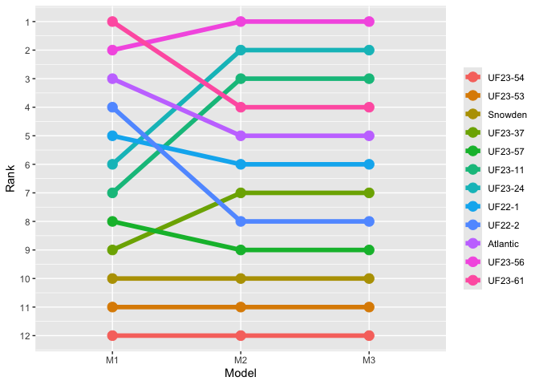

```r
# --- TY
pred = bind_rows(
  predM1.ty %>% select(clone, predicted.value) %>% mutate(model ="M1"),
  predM2.ty %>% select(clone, predicted.value) %>% mutate(model ="M2"),
  predM3.ty %>% select(clone, predicted.value) %>% mutate(model = "M3"))

pred = pred %>%
  group_by(model) %>%
  mutate(rank = rank(-predicted.value, ties.method = "average")) %>%
  ungroup()

ggplot(pred,aes(x = model,y = rank, group = clone, color = clone)) +
  geom_line(size = 2) +
  geom_point(size = 4) +
scale_y_reverse(breaks = 1:12, limits = c(12,1)) +
  labs(x = "Model", y = "Rank")+
  theme(legend.title = element_blank())
```

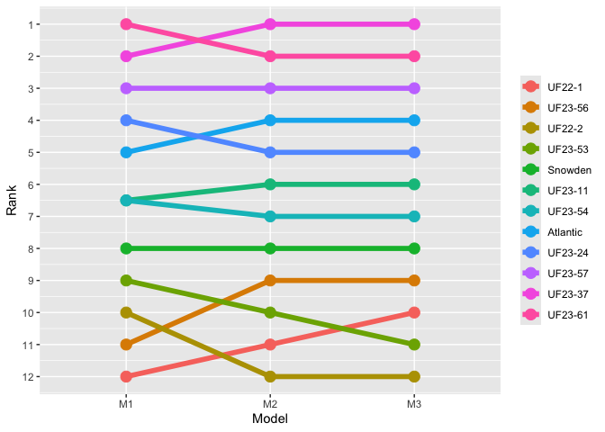

```r
pred = bind_rows(
  predM1.sg %>% select(clone, predicted.value) %>% mutate(model ="M1"),
  predM2.sg %>% select(clone, predicted.value) %>% mutate(model ="M2"),
  predM3.sg %>% select(clone, predicted.value) %>% mutate(model = "M3"))

pred = pred %>%
  group_by(model) %>%
  mutate(rank = rank(-predicted.value, ties.method = "average")) %>%
  ungroup()

ggplot(pred,aes(x = model,y = rank, group = clone, color = clone)) +
  geom_line(size = 2) +
  geom_point(size = 4) +
scale_y_reverse(breaks = 1:12, limits = c(12,1)) +
  labs(x = "Model", y = "Rank")+
  theme(legend.title = element_blank())
```